# Chapter 3: Multiple Regression

## Simple vs. Multiple Regression

### **Simple Linear Model**

Predict \(Y\) using a linear function of a single predictor \(X\): \[Y = \beta_0 + \beta_1 X + \varepsilon\]

where \(\varepsilon \sim N(0, \sigma_\varepsilon)\) and independent.

Need three parameter estimates: \(\hat{\beta}_0, \hat{\beta}_1\) and \(\hat{\sigma}_\varepsilon\).

### **Mutiple Regression Model**

Predict \(Y\) using \(k\) predictors \(X_1, X_2, \ldots, X_k\): \[Y = \beta_0 + \beta_1 X_1 + \beta_2 X_2 + \cdots + \beta_k X_k + \varepsilon\]

where \(\varepsilon \sim N(0, \sigma_\varepsilon)\) and independent.

Need \(k+2\) parameter estimates: \(\hat{\beta}_0, \hat{\beta}_1, \hat{\beta}_2, \ldots \hat{\beta}_k\), and \(\hat{\sigma}_\varepsilon\).

## Mutiple Regression Model

Our prediction equation with \(k\) predictors has the form:

\[\hat{Y} = \hat{\beta}_0 + \hat{\beta}_1 X_1 + \hat{\beta}_2 X_2 + \cdots + \hat{\beta}_k X_k\]

- As was the case with simple linear regression, the coefficients \(\hat{\beta}_i\) are chosen to minimize \(SSE = \sum(Y-\hat{Y})^2\). (Least squares solution)
- Estimate for standard error of the residuals: \[\hat{\sigma}_\varepsilon = \sqrt{MSE} = \sqrt{\frac{SSE}{df}} = \sqrt{\frac{\sum{(Y-\hat{Y})^2}}{n-k-1}}\]
- Degrees of freedom decrease by 1 for each additional predictor.
- Note that in the expressions above, the formula for \(SSE\) is now more complicated: \[SSE = \sum(Y - (\hat{\beta}_0 + \hat{\beta}_1 X_1 + \hat{\beta}_2 X_2 + \cdots + \hat{\beta}_k X_k))^2\]

## Pulse Data

Students in a statistics class recorded resting pulse rates (in class), did three “laps” walking up/down a nearby set of stairs, and then measured their pulse rate after the exercise. They provided additional information about height, weight, exercise, and smoking habits via a survey.

- For today, we’ll model the active pulse (`Active`) as a function of resting pulse (`Rest`), height in inches (`Hgt`), and biological sex (`Sex`, where 1 = female and 0 = male).

  ```r
      library(Stat2Data)
      data("Pulse")
      lm(Active ~ Rest + Hgt + Sex, data=Pulse)
  ```

  ```
  ##
  ## Call:
  ## lm(formula = Active ~ Rest + Hgt + Sex, data = Pulse)
  ##
  ## Coefficients:
  ## (Intercept)         Rest          Hgt          Sex
  ##     -6.3726       1.1300       0.2685       4.4610
  ```

- Regression equation: \[\widehat{Active} = -6.37 + 1.13 \times Rest + 0.268 \times Hgt + 4.46 \times Sex\]

## Pulse Multiple Regression Model

```r
model <- lm(Active ~ Rest + Hgt + Sex, data=Pulse)
summary(model)
```

```
##
## Call:
## lm(formula = Active ~ Rest + Hgt + Sex, data = Pulse)
##
## Residuals:
##     Min      1Q  Median      3Q     Max
## -35.287  -9.637  -2.219   7.221  64.993
##
## Coefficients:
##             Estimate Std. Error t value Pr(>|t|)
## (Intercept)  -6.3726    30.8934  -0.206    0.837
## Rest          1.1300     0.1023  11.042   <2e-16 ***
## Hgt           0.2685     0.4074   0.659    0.511
## Sex           4.4610     2.9947   1.490    0.138
## ---
## Signif. codes:  0 '***' 0.001 '**' 0.01 '*' 0.05 '.' 0.1 ' ' 1
##
## Residual standard error: 15.01 on 228 degrees of freedom
## Multiple R-squared:  0.3724, Adjusted R-squared:  0.3641
## F-statistic:  45.1 on 3 and 228 DF,  p-value: < 2.2e-16
```

## Regression Standard Error

From the output on the previous slide, the regression standard error for the model is \(\hat{\sigma}_\varepsilon = 15.01\) with \(232 - 3 - 1 = 228\) degrees of freedom.

This can be computed directly using the formula \[\hat{\sigma}_\varepsilon = \sqrt{MSE} = \sqrt{\frac{SSE}{df}} = \sqrt{\frac{\sum{(Y-\hat{Y})^2}}{n-k-1}}\] and doing the computations in R:

```r
SSE = sum((Pulse$Active - fitted(model))^2)
df_E = nrow(Pulse)-3-1
sqrt(SSE/df_E)
```

```
## [1] 15.00746
```

## Test for Correlation for One Predictor

We can test \(H_0: \rho=0\) vs. \(H_a: \rho \neq 0\) for a single predictor in exactly the same way as we did with simple linear regression:

```r
cor.test(Pulse$Active, Pulse$Hgt)
```

```
##
##  Pearson's product-moment correlation
##
## data:  Pulse$Active and Pulse$Hgt
## t = -2.7881, df = 230, p-value = 0.005745
## alternative hypothesis: true correlation is not equal to 0
## 95 percent confidence interval:
##  -0.30256468 -0.05325377
## sample estimates:
##        cor
## -0.1808122
```

The correlation is \(r = -0.181\) and the p-value for the test is \(0.0057\), indicating that there is a statistically significant negative association between height and active pulse rate.

## Test for Slope for One Predictor

We can also test \(H_0: \beta_i=0\) vs. \(H_a: \beta_i \neq 0\) for the coefficient for a single predictor \(X_i\) in a multiple regression model. The test statistic is

\[t = \frac{\text{parameter estimate}}{\text{standard error of estimate}} = \frac{\hat{\beta}_i}{SE(\hat{\beta}_i)}.\]

If the conditions for the multiple regression linear model (including normality of the errors) hold, this p-value can be computed using a t-distribution with \(n - k - 1\) degrees of freedom.

## Test for Slope for One Predictor

Let’s test whether the coefficient for `Height` in our `Pulse` model is significantly different from 0. That is, we test \(H_0: \beta_{Hgt}=0\) vs. \(H_a: \beta_{Hgt} \neq 0\). Below is a portion of the output from the summary of our linear model:

```
## [1] Coefficients:
## [2]             Estimate Std. Error t value Pr(>|t|)
## [3] (Intercept)  -6.3726    30.8934  -0.206    0.837
## [4] Rest          1.1300     0.1023  11.042   <2e-16 ***
## [5] Hgt           0.2685     0.4074   0.659    0.511
## [6] Sex           4.4610     2.9947   1.490    0.138
```

Line [5] of the output above shows that our test statistic is \[t = \frac{0.2685}{0.4074} = 0.659,\] which yields a p-value of 0.511. Which such a large p-value, we have no significant evidence that `Height` makes a statistically significant contribution to our model for predicting `Active` pulse rate (once resting pulse rate and sex have already been taken into account).

## What is going on?

**Test #1:** Compute and test the correlation between `Hgt` and `Active` pulse rates. (p-value 0.0057)

**Test #2:** Compute and test the coefficient of `Hgt` in a multiple regression model (along with `Rest` and `Sex`) to predict `Active` pulse rates. (p-value 0.511)

- In simple linear regression, these two tests are completely equivalent – they ALWAYS yield exactly the same *t* statistic and exactly the same p-value.
- When testing correlation, we found a statistically significant negative association between `Height` and `Active` pulse rate (which means that `Height` is in some sense a “useful” predictor of `Active` pulse rate), but when testing the coefficient in our model, we found that `Height` is not a “useful” (statistically significant) predictor of `Active` pulse rates *in this model*.
- What does this mean? *On its own*, `Height` would be a useful predictor. However, *after accounting for resting pulse and sex*, `Height` adds no significant *additional* information to the model.

## Confidence Intervals for Coefficients \(\beta_i\)

A confidence interval for the actual value of any multiple regression coefficient \(\beta_i\) has the form \[\hat{\beta}_i \pm t^* \times SE_{\hat{\beta}_i}\] where the value of \(t^*\) is the critical value from the t-distribution with \(n - k - 1\) degrees of freedom (where \(k\) is the number of predictors). The value of \(SE_{\hat{\beta}_i}\) (the standard error of the coefficient) will be obtained from R (we will not look at the actual formulas).

## Confidence Intervals for Coefficients \(\beta_i\)

**Example:** Find a 95% confidence interval for \(\beta_{Hgt}\) for the `Pulse` model. The key line from the summary of the model is reproduced again below:

```
## [1]             Estimate Std. Error t value Pr(>|t|)
## [2] Hgt           0.2685     0.4074   0.659    0.511
```

Next, we find the value of \(t^*\):

```r
qt(.975,df=228)
```

```
## [1] 1.970423
```

\[\hat{\beta}_i \pm t^* \times SE_{\hat{\beta}_i} = 0.2685 \pm 1.970 \times 0.4074 = (-0.534, 1.071)\] We are 95% confident that the actual value of the coefficient for `Height` in a model that also includes `Rest` and `Sex` is between -0.534 and 1.071. Note that 0 is contained in this interval; this is consistent with the large p-value that we found when testing a null hypothesis that \(\beta_{Hgt} = 0\).

## Confidence Intervals for Coefficients \(\beta_i\)

The computations from the previous slide could be done in R as follows:

```r
0.2685 + qt(c(.025,.975), df=228)*0.4074
```

```
## [1] -0.5342504  1.0712504
```

We can also use the same built-in R function that we used with simple linear regression to compute confidence intervals for all of the coefficients in a model:

```r
confint(model, level = 0.95)
```

```
##                   2.5 %    97.5 %
## (Intercept) -67.2455813 54.500403
## Rest          0.9283411  1.331619
## Hgt          -0.5342865  1.071221
## Sex          -1.4399371 10.361908
```

## Confidence and Prediction Intervals

Suppose that we wish to predict the `Active` pulse rate for a male who is 6 feet tall with a resting pulse rate of 59 beats per minute. Confidence and prediciton intervals are obtained in the same way as in simple linear regression and have the same interpretation:

```r
predict(model, data.frame(Rest=59, Sex=0, Hgt=72), interval="prediction")
```

```
##        fit      lwr      upr
## 1 79.62586 49.88793 109.3638
```

```r
predict(model, data.frame(Rest=59, Sex=0, Hgt=72), interval="confidence")
```

```
##        fit      lwr      upr
## 1 79.62586 76.47977 82.77195
```

## Conditions for Multiple Regression Models

Conditions are similar to those for simple linear regression:

- **“Linearity”:** Much more complicated than in simple linear regression. Is the model \[Y = \beta_0 + \beta_1 X_1 + \beta_2 X_2 + \cdots + \beta_k X_k + \varepsilon\] the right form? Generally not possible to visualize!
  - `Pulse` data: fitting a 3-dimensional space (a “hyperplane”) to data in 4 dimensions…
  - Plot residuals (regular, standardized, or studentized) versus fitted values. Are there patterns or curvature?
  - Are 2-dimensional relationships between \(Y\) and individual predictors \(X_i\) linear? (This does NOT guarantee that the higher dimensional relationship is linear, but if this fails in 2d it almost certainly also fails in higher dimensions.)
- **Normality of residuals:** Assessed in the same manner as before.
- **Constant variance of residuals:** Assessed in the same manner as before.
- **Independence:** Residuals/errors for different observations are completely unrelated to each other.

Also look for outliers and influential points which may be problematic for the model.

## Conditions for Multiple Regression Models

Plots of residuals vs. fitted values: same as in simple linear regression!

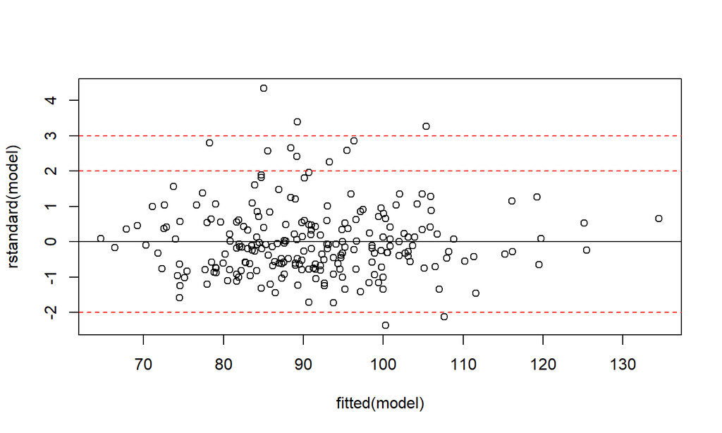

```r
plot(rstandard(model) ~ fitted(model))
abline(h=0)
abline(h=c(-3,-2,2,3), col="red", lty=2)
```

## Conditions for Multiple Regression Models

Based on the plots below, the residuals appear to be somewhat skewed to the right, so the normality condition does not hold particularly well. May impact accuracy of significance tests and intervals.

```
## [1] 74 12
```

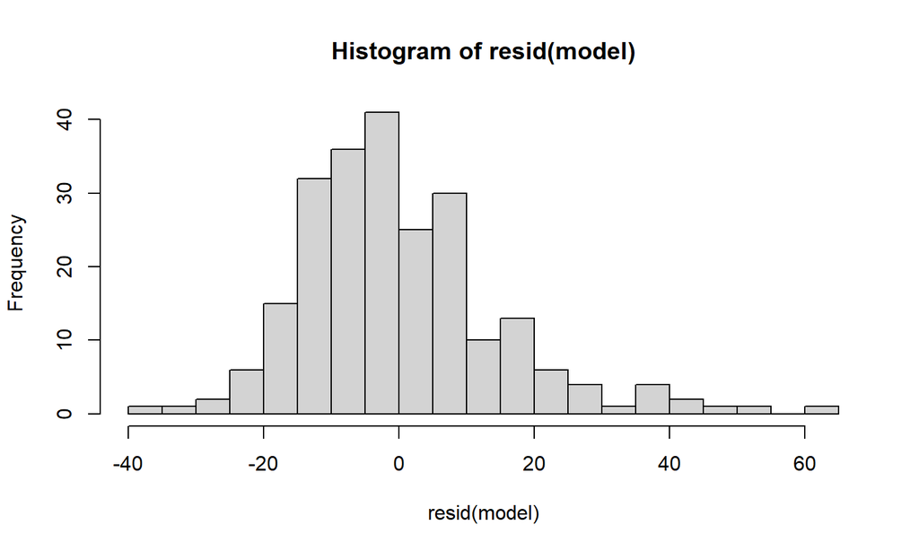

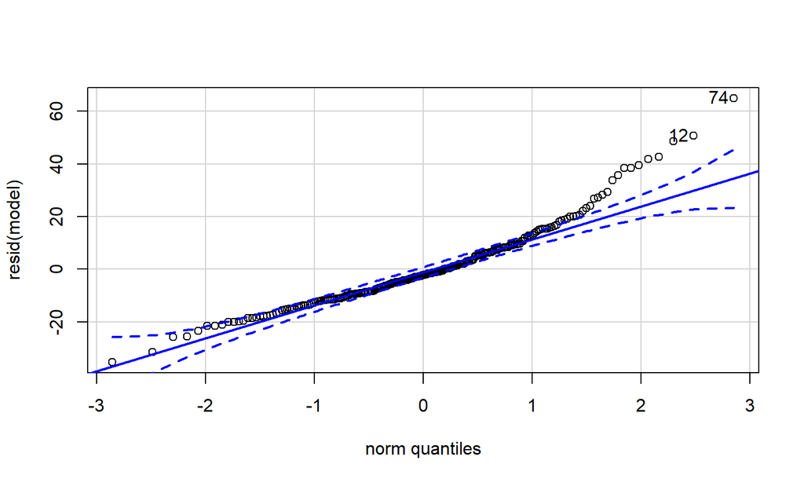

```r
hist(resid(model), breaks=25)
library(car)
qqPlot(resid(model))
```

## ANOVA for Multiple Regression

As was the case with simple linear regression, we can partition the variability in our data into \(SST = SSM + SSE\), where \[SSM = \sum{(\hat{y}-\bar{y})^2}\] \[SSE = \sum{(y-\hat{y})^2}\] \[SST = \sum{(y-\bar{y})^2}\] The formulas above are exactly the same as in simple linear regression, but the degrees of freedom change slightly. We still have a total of \(n-1\) degrees of freedom, but we now have \(k\) degrees of freedom for a model with \(k\) predictors, leaving \(n-k-1\) degrees of freedom for the errors.

## ANOVA for Multiple Regression

For multiple regression, we can use an ANOVA test to test the overall effectiveness of a model with \(k\) predictors. We will test the following hypotheses:

\(H_0: \beta_1 = \beta_2 = \cdots = \beta_k = 0\)

\(H_a:\) at least one \(\beta_i \neq 0\)

The null hypothesis essentially says that none of our predictors has any linear relationship with the response \(Y\), while the alternative says that at least one of them does.

As was the case with simple linear regression, our test statistic will be \(F = MSM/MSE\). However, the degrees of freedom have changed: \[F = \frac{MSM}{MSE} = \frac{SSM/k}{SSE/(n-k-1)}.\] If the conditions for the multiple linear model hold, including normality of the errors, the p-value for the ANOVA test can be computed using the upper tail of an F distribution with \(k\) and \(n-k-1\) degrees of freedom.

## ANOVA for Multiple Regression

For our *Pulse* model predicting *Active* from *Rest*, *Hgt*, and *Sex*, we have a sample size of \(n=232\) with \(k=3\) predictors. Our F statistic and p-value can be computed as follows:

```r
F.stat <- (sum((fitted(model) - mean(Pulse$Active))^2)/3)/
      (sum((Pulse$Active - fitted(model))^2)/(232-3-1))
p.value <- 1-pf(F.stat, df1=3, df2=228)
c(F.stat, p.value)
```

```
## [1] 45.09507  0.00000
```

R reports these values automatically as a part of the summary of any linear model. The last line of the output from the summary of the model shown (the rest of the output, shown on a previous slide, is omitted here).

```r
summary(model)
```

```
## [1] F-statistic:  45.1 on 3 and 228 DF,  p-value: < 2.2e-16
```

## ANOVA for Multiple Regression

The ANOVA table provided by R looks a little different from the tables presented in the textbook on p. 102-103. The output in R shows *sequential sums of squares*, where the sums of squares for the model are further partitioned into the amount of additional variability “explained” by each individual predictor when they are added into the model one at a time (sequentially) in the order listed.

```r
anova(model)
```

```
## Analysis of Variance Table
##
## Response: Active
##            Df Sum Sq Mean Sq  F value Pr(>F)
## Rest        1  29868 29867.9 132.6144 <2e-16 ***
## Hgt         1    102   101.8   0.4519 0.5021
## Sex         1    500   499.8   2.2189 0.1377
## Residuals 228  51351   225.2
## ---
## Signif. codes:  0 '***' 0.001 '**' 0.01 '*' 0.05 '.' 0.1 ' ' 1
```

From this table, the sum of squared errors is \(SSE = 51351\). The model sum of squares is \(SSM = 29868 + 102 + 500 = 30470\), and the total sum of squares is \(SST = 51351 + 30470 = 81821\).

## Three Tests

We have looked at three types of tests of sgnificance for multiple regression:

- **Test for correlation:** Compares a one variable model using one of your predictors vs. a model with no predictors. Useful for identifying predictors which (individually) have a significant positive or negative association with the response.
- **Test for a single coefficient \(\beta\):** Compares a \(k\) variable model with a \(k-1\) variable model in which one predictor is removed. Useful for determining whether a predictor explains significant *additional* variation in the response *after the other variables in the model have already been taken into account.*
- **Overall ANOVA test of the model:** Compares the entire \(k\) variable model vs. a model with no predictors.

In addition to these three tests, there is a more general version of the ANOVA test which can be used to compare any two “nested” models. Two models are called **nested** if one model (the *reduced model*) can be obtained from the other model (the *full model*) by placing restrictions on the coefficients of the *full model*. Most commonly, a reduced model is obtained by setting some of the coefficients \(\beta_i\) equal to 0, which is equivalent to removing some of the predictors from the model.

## Pulse Model: Comparing Nested Models

```
##
## Call:
## lm(formula = Active ~ Rest + Hgt + Sex, data = Pulse)
##
## Residuals:
##     Min      1Q  Median      3Q     Max
## -35.287  -9.637  -2.219   7.221  64.993
##
## Coefficients:
##             Estimate Std. Error t value Pr(>|t|)
## (Intercept)  -6.3726    30.8934  -0.206    0.837
## Rest          1.1300     0.1023  11.042   <2e-16 ***
## Hgt           0.2685     0.4074   0.659    0.511
## Sex           4.4610     2.9947   1.490    0.138
## ---
## Signif. codes:  0 '***' 0.001 '**' 0.01 '*' 0.05 '.' 0.1 ' ' 1
##
## Residual standard error: 15.01 on 228 degrees of freedom
## Multiple R-squared:  0.3724, Adjusted R-squared:  0.3641
## F-statistic:  45.1 on 3 and 228 DF,  p-value: < 2.2e-16
```

From the output above, it appears that neither *Hgt* (*t* = 0.659, df = 228, *p* = 0.511) nor *Sex* (*t* = 1.490, df = 228, *p* = 0.138) makes a significant contribution to the model. Let’s compare this “full” model to a simpler “reduced” model using only *Rest* as a predictor.

## Comparing Nested Models

Given two nested models, we will always have \(SSE_{reduced} > SSE_{full}\), since the additional variables in the full model explain some additional variability in the response and reduce the size of the errors. We’ll call the difference \(SSE_{reduced} - SSE_{full}\) the *extra sum of squares* explained by the full model over the reduced model, and denote this quantity by \(SSM_{extra}\). We then have \[SSE_{reduced} = SSM_{extra} + SSE_{full}.\] We have partitioned the variability of the errors in the reduced model into two parts: (1) the additional variability that can be explained by the more complicated full model (measured by $SSM_{extra}), and (2) the remaining variability of errors in the full model (measured by \(SSE_{full}\). The degrees of freedom for the extra sum of squares is the difference between the degrees of freedom for the two models, which is typically the number of variables removed from the full model to obtain the reduced model.

We then compute the following test statistic for comparing the reduced model vs. the full model: \[F = \frac{MSM_{extra}}{MSE_{full}} = \frac{SSM_{extra}/(\text{df of }SSM_{extra})}{SSE_{full}/(\text{df of }SSM_{full})}.\] If the conditions for the multiple linear model hold, the p-value for the ANOVA test can be computed using the upper tail of an F distribution with numerator degrees of freedom given by the difference in error df between the two models and denominator degrees of freedom given by the error df of the full model.

## Pulse Model: Comparing Nested Models

```r
anova(model)
```

```
## Analysis of Variance Table
##
## Response: Active
##            Df Sum Sq Mean Sq  F value Pr(>F)
## Rest        1  29868 29867.9 132.6144 <2e-16 ***
## Hgt         1    102   101.8   0.4519 0.5021
## Sex         1    500   499.8   2.2189 0.1377
## Residuals 228  51351   225.2
## ---
## Signif. codes:  0 '***' 0.001 '**' 0.01 '*' 0.05 '.' 0.1 ' ' 1
```

```r
m.reduced <- lm(Active ~ Rest, data=Pulse)
anova(m.reduced)
```

```
## Analysis of Variance Table
##
## Response: Active
##            Df Sum Sq Mean Sq F value    Pr(>F)
## Rest        1  29868 29867.9  132.23 < 2.2e-16 ***
## Residuals 230  51953   225.9
## ---
## Signif. codes:  0 '***' 0.001 '**' 0.01 '*' 0.05 '.' 0.1 ' ' 1
```

## Pulse Model: Comparing Nested Models

From the output on the previous slide, the sum of squared errors for the full model (with three predictors) is \(SSE_{full} = 51351\) with 228 df, and the sum of squared errors for the reduced model (with only one predictor) is \(SSE_{reduced} = 51953\) with 230 df. The extra sum of squares is the difference between these two values is \(SSM_{extra} = SSE_{reduced} - SSE_{full} = 51953 - 51351 = 602\).Note that the \(SSM_{extra}\) can also be obtained by adding together the sequential sums of squares for *Hgt* (102) and *Sex* (500) from the ANOVA table for the full model. The degrees of freedom for the extra sum of squares is the difference between the degrees of freedom for the two models, which in this case is 2 (the number of variables removed from the full model to obtain the reduced model).

We now wish to test whether the full model provides a statistically significant improvement over the reduced model. That is, we will test \(H_0: \beta_{Hgt} = \beta_{Sex} = 0\) vs. and alternative hypothesis that at least one of the two coefficients is nonzero. Our F-statistic for the test is \[F = \frac{MSM_{extra}}{MSE_{full}} = \frac{SSM_{extra}/(\text{df of }SSM_{extra})}{SSE_{full}/(\text{df of }SSM_{full})} = \frac{602/2}{51351/228} = 1.336.\]

```r
1 - pf(1.336, df1 = 2, df2 = 228)
```

```
## [1] 0.2649452
```

## Pulse Model: Comparing Nested Models

The computations from the previous page to compare nested models can also be done by R. Two compare two nested models “m1” and “m2”, use the command “anova(m1, m2)”, where the reduced model is listed first and the full model second. For the *Pulse* example:

```r
anova(m.reduced, model)
```

```
## Analysis of Variance Table
##
## Model 1: Active ~ Rest
## Model 2: Active ~ Rest + Hgt + Sex
##   Res.Df   RSS Df Sum of Sq      F Pr(>F)
## 1    230 51953
## 2    228 51351  2    601.54 1.3354 0.2651
```

With such a large p-value, we see that the three variable model (with *Rest*, *Hgt*, and *Sex* as predictors) does not provide a statistically significant improvement over the one variable model using *Rest* alone.

## Coefficient of Determination \(R^2\)

The definition of the **coefficient of determination** \(R^2\) that we encountered for simple linear regression extends nicely to multiple regression as well: \[R^2 = \frac{\text{Varibility explained by model}}{\text{Total variability in response }y} = \frac{\sum(\hat{y}_i - \bar{y})^2}{\sum(y_i - \bar{y})^2} = \frac{SSM}{SST} = 1 - \frac{SSE}{SST}\]

For our three predictor *Pulse* model, the value of \(R^2\) can be computed as follows:

```r
1 - sum((resid(model))^2/sum((Pulse$Active - mean(Pulse$Active))^2))
```

```
## [1] 0.372394
```

This matches the value reported in the regression output on previous pages. The linear model for predicting *Active* pulse rate from *Rest*, *Hgt*, and *Sex* explains 37.2% of the overall variation in *Active* pulse rates.

## Why is it called \(R^2\)?

In simple linear regression, recall that \(R^2\) is the square of the correlation coefficient \(r\) between the response \(Y\) and the predictor \(X\). Since correlation is inherently a relationship between two variables, this no longer even makes sense in the context of multiple regression. However, a closely related fact remains true.

A key fact about correlation is that it is invariant under linear transformations. That is, as long as \(b \neq 0\), \[Cor(Y,X) = Cor(Y,a+bX).\] But this means that when we fit a regression line \(\hat{Y}=\hat{\beta}_0+\hat{\beta}_1 X\), we have \[Cor(Y,X) = Cor(Y,\hat{\beta}_0+\hat{\beta}_1 X) = Cor(Y,\hat{Y}).\] Thus in simple linear regression, the correlation between the response \(Y\) and the predictor \(X\) is always equal to the correlation between the response \(Y\) and the fitted values \(\hat{Y}\). So \(R^2\) is equal to the square of the correlation between the response \(Y\) and the fitted values \(\hat{Y}\). This fact carries over to multiple regression as well.

## Why is it called \(R^2\)?

In both simple regression and multiple regression, \(R^2\) is equal to the square of the correlation between the response \(Y\) and the fitted values \(\hat{Y}\).

We verify this in the case of our *Pulse* model:

```r
(cor(Pulse$Active, fitted(model)))^2
```

```
## [1] 0.372394
```

```r
summary(model)$r.squared
```

```
## [1] 0.372394
```

## Adjusted \(R^2\)

Recall that the coefficient of determination \(R^2\) is defined by \[R^2 = \frac{SSM}{SST} = 1 - \frac{SSE}{SST}.\] Note that the ratio \(SSE/SST\) in the expression above tells us the proportion of the variance *in our particular sample* that is *not* accounted for by the model. An alternative way to measure the proportion of variance that is *not* accounted for by the model is to divide both the numerator and denominator of this expression by their degrees of freedom. This yields the following quantity, which is known as **adjusted \(R^2\)**:  
\[R_{adj}^2 = 1 - \frac{SSE/(n-k-1)}{SST/(n-1)} = 1-\frac{\hat{\sigma}_\varepsilon}{S_Y^2}.\] One way to account for the fact that \(R^2\) always increases when new predictors are added to the model is to adjust the value of \(R^2\) slighty to decrease it slightly for each added predictor

## Lots of Models

[output not shown]